# Lab 1 - Quarto Warmup & STAT 331 Review

Author

Nicholas Soares

```r
library(tidyverse)
library(ggridges)
```

## Quarto

First, let’s make sure you know how to use Markdown formatting to style a Quarto document.

1. **Make this text bold.**
2. *Make this text italicized.*
3. Make these into a bullet point list:
- Apples
- Bananas
- Potatoes
4. Edit the YAML to remove warning messages from being output in the rendered HTML file
5. Using code chunk options, make it so this chunk shows the plot but not the source code:

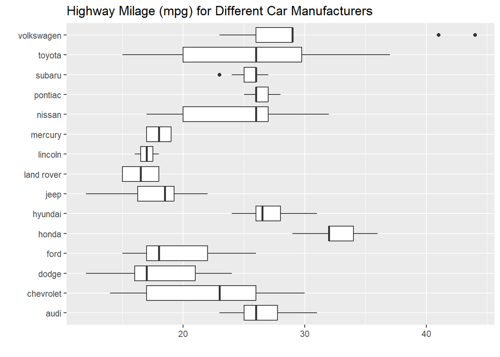

6. Using code chunk options, remove the messages about bandwidth `geom_density_ridges()` chose to use:

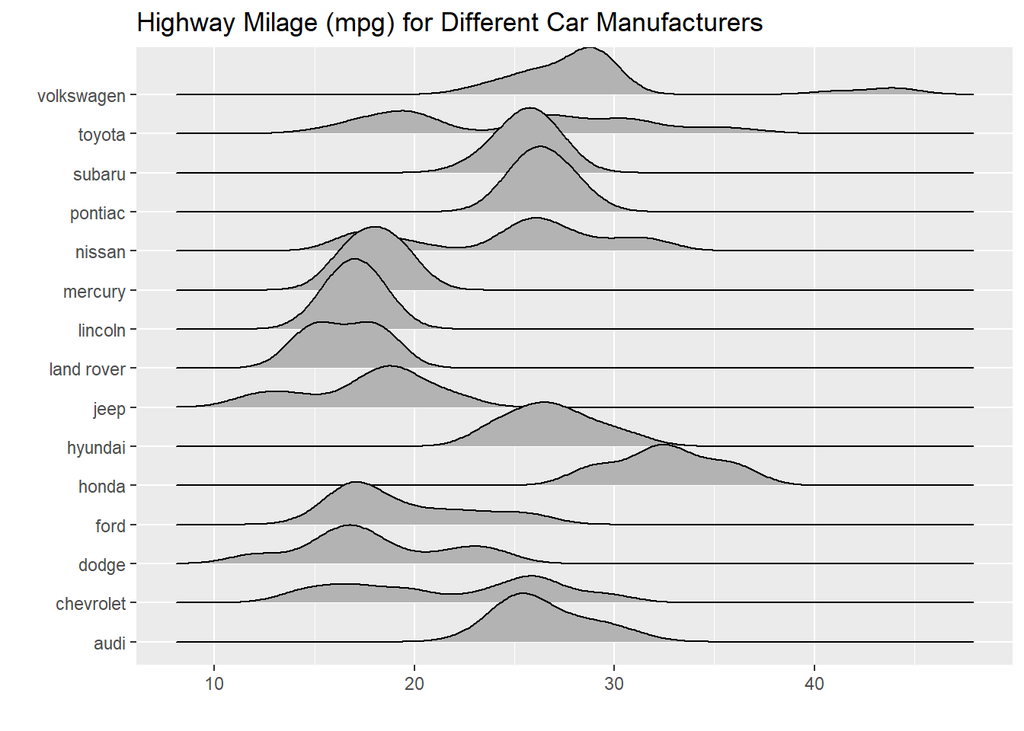

```r
ggplot(data = mpg,
       mapping = aes(y = manufacturer, x = hwy)) +
  geom_density_ridges() +
  labs(x = "",
       y = "",
       title = "Highway Milage (mpg) for Different Car Manufacturers"
       )
```

7. Using code chunk options, make it so that these plots are printed side-by-side:

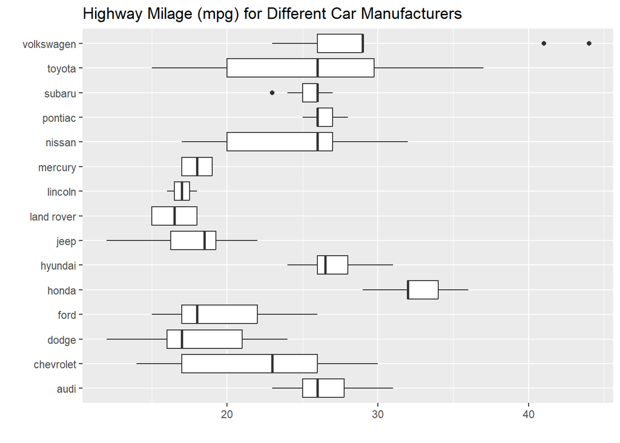

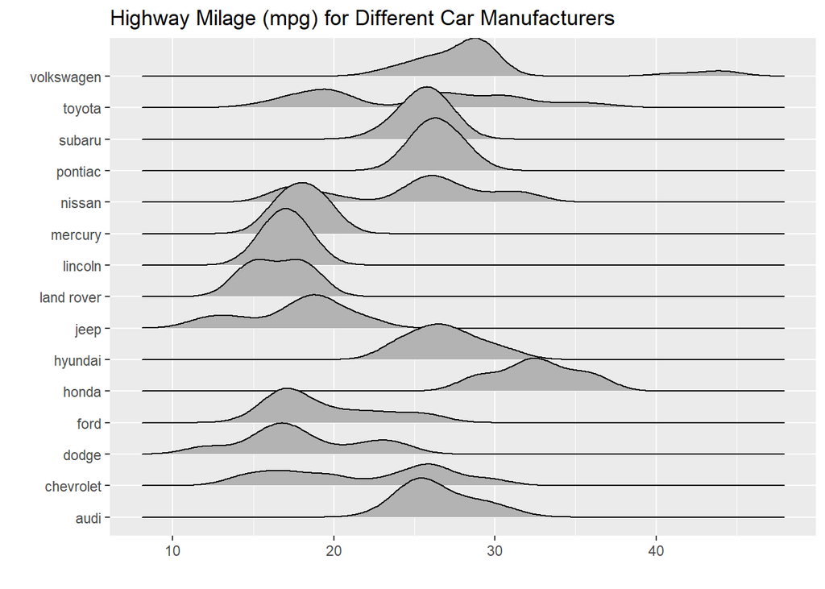

```r
ggplot(data = mpg,
       mapping = aes(y = manufacturer, x = hwy)) +
  geom_boxplot() +
  labs(x = "",
       y = "",
       title = "Highway Milage (mpg) for Different Car Manufacturers"
       )
ggplot(data = mpg,
       mapping = aes(y = manufacturer, x = hwy)) +
  geom_density_ridges() +
  labs(x = "",
       y = "",
       title = "Highway Milage (mpg) for Different Car Manufacturers"
       )
```

8. Using code chunk options, make it so this chunk shows the code but not the output:

```r
2 + 2
```

9. Using code chunk options, make it so the file can still knit even though this chunk has an error

```r
2 + a
```

```
Error: object 'a' not found
```

10. Using code chunk options, create a descriptive `label` for each of the code chunks above.

## Data Wrangling Review

Since you already seen some `ggplot`s, let’s do a bit of review on data handling. In this class, we will exclusively make use of tools from the `tidyverse` suite of packages to perform our data cleaning and wrangling operations. If you are less familiar with these packages or it’s been some time since you used them, I would strongly recommend referencing the function documentation!

For these problems, we will continue to work with the `mpg` data frame, making various changes to the data to clean it up.

11. The `fl` variable describes the type of fuel for each car, with levels: `p`, `r`, `e`, `d`, and `c`. Do some research into what each of these labels mean! Then, use the `if_else()` function to create a new variable (`fuel_type`) with two levels: `petrol` (any car using petrolium-based gas) and `alternative energy` (any car not using petrolium-based gas).

```r
#c: Compressed natural gas (CNG)
#d: Diesel
#e: Ethanol (E85)
#p: Premium gasoline
#r: Regular gasoline

mpg<-mpg|>
  mutate(fuel_type=if_else(mpg$fl%in%c("p","r","d"),"petrol","alternative energy"))
head(mpg)
```

| manufacturer | model | displ | year | cyl | trans | drv | cty | hwy | fl | class | fuel_type |
| --- | --- | --- | --- | --- | --- | --- | --- | --- | --- | --- | --- |
| audi | a4 | 1.8 | 1999 | 4 | auto(l5) | f | 18 | 29 | p | compact | petrol |
| audi | a4 | 1.8 | 1999 | 4 | manual(m5) | f | 21 | 29 | p | compact | petrol |
| audi | a4 | 2.0 | 2008 | 4 | manual(m6) | f | 20 | 31 | p | compact | petrol |
| audi | a4 | 2.0 | 2008 | 4 | auto(av) | f | 21 | 30 | p | compact | petrol |
| audi | a4 | 2.8 | 1999 | 6 | auto(l5) | f | 16 | 26 | p | compact | petrol |
| audi | a4 | 2.8 | 1999 | 6 | manual(m5) | f | 18 | 26 | p | compact | petrol |

12. The `drv` variable describes if the car has front drive (`f`), rear drive (`r`), or four wheel drive (`4`). Let’s make better labels for these values! Specifically, use the `case_when()` function to change the `drv` varible to have the following levels: `front`, `rear`, `four wheel`.

```r
mpg$drv<-case_when(
    mpg$drv == "f" ~ "front",
    mpg$drv == "r" ~ "rear",
    mpg$drv == "4" ~ "four wheel"
)
head(mpg)
```

| manufacturer | model | displ | year | cyl | trans | drv | cty | hwy | fl | class | fuel_type |
| --- | --- | --- | --- | --- | --- | --- | --- | --- | --- | --- | --- |
| audi | a4 | 1.8 | 1999 | 4 | auto(l5) | front | 18 | 29 | p | compact | petrol |
| audi | a4 | 1.8 | 1999 | 4 | manual(m5) | front | 21 | 29 | p | compact | petrol |
| audi | a4 | 2.0 | 2008 | 4 | manual(m6) | front | 20 | 31 | p | compact | petrol |
| audi | a4 | 2.0 | 2008 | 4 | auto(av) | front | 21 | 30 | p | compact | petrol |
| audi | a4 | 2.8 | 1999 | 6 | auto(l5) | front | 16 | 26 | p | compact | petrol |
| audi | a4 | 2.8 | 1999 | 6 | manual(m5) | front | 18 | 26 | p | compact | petrol |

(string split + remove extra “)” ) 13. The `trans` variable contains two pieces of information, (1) the transmission style (`auto` or `manual`) and the specific type of transmission (e.g., `l5`, `m5`). Using the `str_split()` function, create a new variable (`trans_type`) containing the specific type of transmission of each car. Once you’ve made this new variable, use the `rename()` function to change the name of the `trans` column to `trans_style`.  
*Hint: You will need to deal with the stray parenthesis!*

```r
mpg<-mpg|>
  mutate(trans_type=str_split(mpg$trans,'[()]+',simplify = T)[,2])|>
  rename(trans_style=trans)
head(mpg)
```

| manufacturer | model | displ | year | cyl | trans_style | drv | cty | hwy | fl | class | fuel_type | trans_type |
| --- | --- | --- | --- | --- | --- | --- | --- | --- | --- | --- | --- | --- |
| audi | a4 | 1.8 | 1999 | 4 | auto(l5) | front | 18 | 29 | p | compact | petrol | l5 |
| audi | a4 | 1.8 | 1999 | 4 | manual(m5) | front | 21 | 29 | p | compact | petrol | m5 |
| audi | a4 | 2.0 | 2008 | 4 | manual(m6) | front | 20 | 31 | p | compact | petrol | m6 |
| audi | a4 | 2.0 | 2008 | 4 | auto(av) | front | 21 | 30 | p | compact | petrol | av |
| audi | a4 | 2.8 | 1999 | 6 | auto(l5) | front | 16 | 26 | p | compact | petrol | l5 |
| audi | a4 | 2.8 | 1999 | 6 | manual(m5) | front | 18 | 26 | p | compact | petrol | m5 |

## Getting to know your classmates

14. Find someone who took Stat 331 from a different professor than you. Compare your experiences. Tell me their name and professor. List one or two things that you think you learned more about, and one or two things that they learned more about.

Nathan took STAT 331 with Dr. Glanz, but I had taken this class with Dr. Frame. Nathan had learned how to use the twitter package in R, but I feel like we spent more time on regular expressions.

15. Find someone in the class who **does not** share your birth month. Tell me their name and birthday, and use R to find out how many days apart your birthdays are.

Jose’s birthday is on September 4th.

```r
my.bday<-as.Date("Dec 15",format="%b %d")
jose.bday<-as.Date("Sep 4",format="%b %d")
my.bday-jose.bday
```

```
Time difference of 102 days
```